# Bank_Churn_Prediction_Full_code

## Data Preprocessing

#### Column Bining

##### Binning the "Tenure" Column

```python
bins = [0, 1, 3, 5, 7, 10]
labels = ['<1 year', '1-3 years', '3-5 years', '5-7 years', '7+ years']
df['TenureGroup'] = pd.cut(df['Tenure'], bins=bins, labels=labels)
```

```python
# Drop tenure column
df.drop("Tenure", axis=1, inplace=True)
```

```python
df
```

|  | RowNumber | CustomerId | Surname | CreditScore | Geography | Gender | Age | Balance | NumOfProducts | HasCrCard | IsActiveMember | EstimatedSalary | Exited | TenureGroup |
| --- | --- | --- | --- | --- | --- | --- | --- | --- | --- | --- | --- | --- | --- | --- |
| 0 | 1 | 15634602 | Hargrave | 619 | France | Female | 42 | 0.00 | 1 | 1 | 1 | 101348.88 | 1 | 1-3 years |
| 1 | 2 | 15647311 | Hill | 608 | Spain | Female | 41 | 83807.86 | 1 | 0 | 1 | 112542.58 | 0 | <1 year |
| 2 | 3 | 15619304 | Onio | 502 | France | Female | 42 | 159660.80 | 3 | 1 | 0 | 113931.57 | 1 | 7+ years |
| 3 | 4 | 15701354 | Boni | 699 | France | Female | 39 | 0.00 | 2 | 0 | 0 | 93826.63 | 0 | <1 year |
| 4 | 5 | 15737888 | Mitchell | 850 | Spain | Female | 43 | 125510.82 | 1 | 1 | 1 | 79084.10 | 0 | 1-3 years |
| ... | ... | ... | ... | ... | ... | ... | ... | ... | ... | ... | ... | ... | ... | ... |
| 9995 | 9996 | 15606229 | Obijiaku | 771 | France | Male | 39 | 0.00 | 2 | 1 | 0 | 96270.64 | 0 | 3-5 years |
| 9996 | 9997 | 15569892 | Johnstone | 516 | France | Male | 35 | 57369.61 | 1 | 1 | 1 | 101699.77 | 0 | 7+ years |
| 9997 | 9998 | 15584532 | Liu | 709 | France | Female | 36 | 0.00 | 1 | 0 | 1 | 42085.58 | 1 | 5-7 years |
| 9998 | 9999 | 15682355 | Sabbatini | 772 | Germany | Male | 42 | 75075.31 | 2 | 1 | 0 | 92888.52 | 1 | 1-3 years |
| 9999 | 10000 | 15628319 | Walker | 792 | France | Female | 28 | 130142.79 | 1 | 1 | 0 | 38190.78 | 0 | 3-5 years |

10000 rows × 14 columns

##### Binning the "CreditScore" Column

```python
bins = [300, 579, 669, 739, 799, 850]  # These are common ranges for credit scores
labels = ['Poor', 'Fair', 'Good', 'Very Good', 'Excellent']
df['CreditScore'] = pd.cut(df['CreditScore'], bins=bins, labels=labels)
```

```python
df
```

|  | RowNumber | CustomerId | Surname | CreditScore | Geography | Gender | Age | Balance | NumOfProducts | HasCrCard | IsActiveMember | EstimatedSalary | Exited | TenureGroup |
| --- | --- | --- | --- | --- | --- | --- | --- | --- | --- | --- | --- | --- | --- | --- |
| 0 | 1 | 15634602 | Hargrave | Fair | France | Female | 42 | 0.00 | 1 | 1 | 1 | 101348.88 | 1 | 1-3 years |
| 1 | 2 | 15647311 | Hill | Fair | Spain | Female | 41 | 83807.86 | 1 | 0 | 1 | 112542.58 | 0 | <1 year |
| 2 | 3 | 15619304 | Onio | Poor | France | Female | 42 | 159660.80 | 3 | 1 | 0 | 113931.57 | 1 | 7+ years |
| 3 | 4 | 15701354 | Boni | Good | France | Female | 39 | 0.00 | 2 | 0 | 0 | 93826.63 | 0 | <1 year |
| 4 | 5 | 15737888 | Mitchell | Excellent | Spain | Female | 43 | 125510.82 | 1 | 1 | 1 | 79084.10 | 0 | 1-3 years |
| ... | ... | ... | ... | ... | ... | ... | ... | ... | ... | ... | ... | ... | ... | ... |
| 9995 | 9996 | 15606229 | Obijiaku | Very Good | France | Male | 39 | 0.00 | 2 | 1 | 0 | 96270.64 | 0 | 3-5 years |
| 9996 | 9997 | 15569892 | Johnstone | Poor | France | Male | 35 | 57369.61 | 1 | 1 | 1 | 101699.77 | 0 | 7+ years |
| 9997 | 9998 | 15584532 | Liu | Good | France | Female | 36 | 0.00 | 1 | 0 | 1 | 42085.58 | 1 | 5-7 years |
| 9998 | 9999 | 15682355 | Sabbatini | Very Good | Germany | Male | 42 | 75075.31 | 2 | 1 | 0 | 92888.52 | 1 | 1-3 years |
| 9999 | 10000 | 15628319 | Walker | Very Good | France | Female | 28 | 130142.79 | 1 | 1 | 0 | 38190.78 | 0 | 3-5 years |

10000 rows × 14 columns

#### Encoding categorical variables

```python
# Encoding the categorical variables using one-hot encoding
df = pd.get_dummies(df, drop_first=True)
```

```python
df.head()
```

|  | RowNumber | CustomerId | Age | Balance | NumOfProducts | HasCrCard | IsActiveMember | EstimatedSalary | Exited | Surname_Abbie | ... | CreditScore_Good | CreditScore_Very Good | CreditScore_Excellent | Geography_Germany | Geography_Spain | Gender_Male | TenureGroup_1-3 years | TenureGroup_3-5 years | TenureGroup_5-7 years | TenureGroup_7+ years |
| --- | --- | --- | --- | --- | --- | --- | --- | --- | --- | --- | --- | --- | --- | --- | --- | --- | --- | --- | --- | --- | --- |
| 0 | 1 | 15634602 | 42 | 0.00 | 1 | 1 | 1 | 101348.88 | 1 | False | ... | False | False | False | False | False | False | True | False | False | False |
| 1 | 2 | 15647311 | 41 | 83807.86 | 1 | 0 | 1 | 112542.58 | 0 | False | ... | False | False | False | False | True | False | False | False | False | False |
| 2 | 3 | 15619304 | 42 | 159660.80 | 3 | 1 | 0 | 113931.57 | 1 | False | ... | False | False | False | False | False | False | False | False | False | True |
| 3 | 4 | 15701354 | 39 | 0.00 | 2 | 0 | 0 | 93826.63 | 0 | False | ... | True | False | False | False | False | False | False | False | False | False |
| 4 | 5 | 15737888 | 43 | 125510.82 | 1 | 1 | 1 | 79084.10 | 0 | False | ... | False | False | True | False | True | False | True | False | False | False |

5 rows × 2951 columns

### Dummy Variable Creation

```python
# Create dummy variables
df = pd.get_dummies(df, drop_first=True)
```

```python
df.columns
```

```
Index(['RowNumber', 'CustomerId', 'Age', 'Balance', 'NumOfProducts',
       'HasCrCard', 'IsActiveMember', 'EstimatedSalary', 'Exited',
       'Surname_Abbie',
       ...
       'CreditScore_Good', 'CreditScore_Very Good', 'CreditScore_Excellent',
       'Geography_Germany', 'Geography_Spain', 'Gender_Male',
       'TenureGroup_1-3 years', 'TenureGroup_3-5 years',
       'TenureGroup_5-7 years', 'TenureGroup_7+ years'],
      dtype='object', length=2951)
```

```python
df.shape
```

```
(10000, 2951)
```

```python
# Make the columns 1s and 0s instead of true and false
df = df.replace({False: 0, True: 1})
```

```python
df.head()
```

|  | RowNumber | CustomerId | Age | Balance | NumOfProducts | HasCrCard | IsActiveMember | EstimatedSalary | Exited | Surname_Abbie | ... | CreditScore_Good | CreditScore_Very Good | CreditScore_Excellent | Geography_Germany | Geography_Spain | Gender_Male | TenureGroup_1-3 years | TenureGroup_3-5 years | TenureGroup_5-7 years | TenureGroup_7+ years |
| --- | --- | --- | --- | --- | --- | --- | --- | --- | --- | --- | --- | --- | --- | --- | --- | --- | --- | --- | --- | --- | --- |
| 0 | 1 | 15634602 | 42 | 0.00 | 1 | 1 | 1 | 101348.88 | 1 | 0 | ... | 0 | 0 | 0 | 0 | 0 | 0 | 1 | 0 | 0 | 0 |
| 1 | 2 | 15647311 | 41 | 83807.86 | 1 | 0 | 1 | 112542.58 | 0 | 0 | ... | 0 | 0 | 0 | 0 | 1 | 0 | 0 | 0 | 0 | 0 |
| 2 | 3 | 15619304 | 42 | 159660.80 | 3 | 1 | 0 | 113931.57 | 1 | 0 | ... | 0 | 0 | 0 | 0 | 0 | 0 | 0 | 0 | 0 | 1 |
| 3 | 4 | 15701354 | 39 | 0.00 | 2 | 0 | 0 | 93826.63 | 0 | 0 | ... | 1 | 0 | 0 | 0 | 0 | 0 | 0 | 0 | 0 | 0 |
| 4 | 5 | 15737888 | 43 | 125510.82 | 1 | 1 | 1 | 79084.10 | 0 | 0 | ... | 0 | 0 | 1 | 0 | 1 | 0 | 1 | 0 | 0 | 0 |

5 rows × 2951 columns

### Train-validation-test Split

```python
# defining the dependent and independent variables
X = df.drop(["Exited", "RowNumber", "CustomerId"], axis=1) # Pass a list of column names as strings.
y = df["Exited"]
```

```python
# splitting the data in 80:20 ratio for train and temporary data
x_train, x_temp, y_train, y_temp = train_test_split(X, y, test_size=0.2,random_state=1)
```

```python
# splitting the temporary data in 50:50 ratio for validation and test data
x_val,x_test,y_val,y_test = train_test_split(x_temp,y_temp,test_size=0.5,random_state=1)
```

```python
print("Number of Rows in Train Data =", x_train.shape[0])
print("Number of Rows in Validation Data =", x_val.shape[0])
print("Number of Rows in Test Data =", x_test.shape[0])
```

```
Number of Rows in Train Data = 8000
Number of Rows in Validation Data = 1000
Number of Rows in Test Data = 1000
```

```python
X.columns
```

```
Index(['Age', 'Balance', 'NumOfProducts', 'HasCrCard', 'IsActiveMember',
       'EstimatedSalary', 'Surname_Abbie', 'Surname_Abbott',
       'Surname_Abdullah', 'Surname_Abdulov',
       ...
       'CreditScore_Good', 'CreditScore_Very Good', 'CreditScore_Excellent',
       'Geography_Germany', 'Geography_Spain', 'Gender_Male',
       'TenureGroup_1-3 years', 'TenureGroup_3-5 years',
       'TenureGroup_5-7 years', 'TenureGroup_7+ years'],
      dtype='object', length=2948)
```

### Data Normalization

```python
# List of numerical features to scale (e.g., numerical features)
num_columns = ['Age', 'Balance', 'EstimatedSalary', 'NumOfProducts']
```

```python
# Initialize the StandardScaler
scaler = StandardScaler()

# Fit the scaler to the selected columns in the x_train data
scaler.fit(x_train[num_columns])
```

```
StandardScaler()
```

```python
# Transform selected columns in x_train, x_val, and x_test using the fitted scaler

x_train[num_columns] = scaler.transform(x_train[num_columns])

x_val[num_columns] = scaler.transform(x_val[num_columns])

x_test[num_columns] = scaler.transform(x_test[num_columns])
```

```python
x_train.head()
```

|  | Age | Balance | NumOfProducts | HasCrCard | IsActiveMember | EstimatedSalary | Surname_Abbie | Surname_Abbott | Surname_Abdullah | Surname_Abdulov | ... | CreditScore_Good | CreditScore_Very Good | CreditScore_Excellent | Geography_Germany | Geography_Spain | Gender_Male | TenureGroup_1-3 years | TenureGroup_3-5 years | TenureGroup_5-7 years | TenureGroup_7+ years |
| --- | --- | --- | --- | --- | --- | --- | --- | --- | --- | --- | --- | --- | --- | --- | --- | --- | --- | --- | --- | --- | --- |
| 2694 | -0.944500 | 0.588173 | 0.802257 | 0 | 1 | 0.427394 | 0 | 0 | 0 | 0 | ... | 0 | 0 | 0 | 1 | 0 | 1 | 1 | 0 | 0 | 0 |
| 5140 | -0.944500 | 0.469849 | 0.802257 | 0 | 0 | -1.025487 | 0 | 0 | 0 | 0 | ... | 0 | 0 | 0 | 0 | 0 | 0 | 0 | 1 | 0 | 0 |
| 2568 | 0.774987 | 0.858788 | -0.911510 | 1 | 1 | -0.944798 | 0 | 0 | 0 | 0 | ... | 0 | 0 | 0 | 1 | 0 | 0 | 0 | 0 | 1 | 0 |
| 3671 | 1.252622 | 0.565604 | 0.802257 | 0 | 1 | -0.551946 | 0 | 0 | 0 | 0 | ... | 0 | 0 | 0 | 1 | 0 | 0 | 0 | 0 | 1 | 0 |
| 7427 | -0.562392 | 0.730395 | -0.911510 | 0 | 0 | 1.083383 | 0 | 0 | 0 | 0 | ... | 1 | 0 | 0 | 0 | 1 | 1 | 0 | 0 | 0 | 1 |

5 rows × 2948 columns

### Utility functions

```python
def plot(history, name):
    """
    Function to plot loss/accuracy

    history: an object which stores the metrics and losses.
    name: can be one of Loss or Accuracy
    """
    fig, ax = plt.subplots() #Creating a subplot with figure and axes.
    plt.plot(history.history[name]) #Plotting the train accuracy or train loss
    plt.plot(history.history['val_'+name]) #Plotting the validation accuracy or validation loss

    plt.title('Model ' + name.capitalize()) #Defining the title of the plot.
    plt.ylabel(name.capitalize()) #Capitalizing the first letter.
    plt.xlabel('Epoch') #Defining the label for the x-axis.
    fig.legend(['Train', 'Validation'], loc="outside right upper") #Defining the legend, loc controls the position of the legend.
```

```python
# function to compute adjusted R-squared
def adj_r2_score(predictors, targets, predictions):
    r2 = r2_score(targets, predictions)
    n = predictors.shape[0]
    k = predictors.shape[1]
    return 1 - ((1 - r2) * (n - 1) / (n - k - 1))


# function to compute MAPE
def mape_score(targets, predictions):
    return np.mean(np.abs(targets - predictions) / targets) * 100


# function to compute different metrics to check performance of a neural network model
def model_performance(model,predictors,target):
    """
    Function to compute different metrics to check regression model performance

    model: regressor
    predictors: independent variables
    target: dependent variable
    """
    # predicting using the independent variables
    pred = model.predict(predictors).reshape(-1)

    r2 = r2_score(target, pred)  # to compute R-squared
    adjr2 = adj_r2_score(predictors, target, pred)  # to compute adjusted R-squared
    rmse = np.sqrt(mean_squared_error(target, pred))  # to compute RMSE
    mae = mean_absolute_error(target, pred)  # to compute MAE
    mape = mape_score(target, pred)  # to compute MAPE

    # creating a dataframe of metrics
    df_perf =  {
            "RMSE": [rmse],
            "MAE": [mae],
            "R-squared": [r2],
            "Adj. R-squared": [adjr2],
            "MAPE": [mape]}

    return df_perf

columns = ["# hidden layers","# neurons - hidden layer","activation function - hidden layer ","# epochs","batch size","optimizer","time(secs)","Train_loss","Valid_loss"]

results = pd.DataFrame(columns=columns)
```

```python
# defining a function to compute different metrics to check performance of a classification model built using statsmodels
def model_performance_classification(
    model, predictors, target, threshold=0.5
):
    """
    Function to compute different metrics to check classification model performance

    model: classifier
    predictors: independent variables
    target: dependent variable
    threshold: threshold for classifying the observation as class 1
    """

    # checking which probabilities are greater than threshold
    pred = model.predict(predictors) > threshold
    # pred_temp = model.predict(predictors) > threshold
    # # rounding off the above values to get classes
    # pred = np.round(pred_temp)

    acc = accuracy_score(target, pred)  # to compute Accuracy
    recall = recall_score(target, pred, average='weighted')  # to compute Recall
    precision = precision_score(target, pred, average='weighted')  # to compute Precision
    f1 = f1_score(target, pred, average='weighted')  # to compute F1-score

    # creating a dataframe of metrics
    df_perf = pd.DataFrame(
        {"Accuracy": acc, "Recall": recall, "Precision": precision, "F1 Score": f1,},
        index=[0],
    )

    return df_perf
```

## Model Building

### Model Evaluation Criterion

Write down the logic for choosing the metric that would be the best metric for this business scenario.

- Recall is the best metric for this business scenario of identifying customers that will churn or not over half a year. Missing out on customers who are about to leave (false negatives) could be very vital, as retaining existing customers is typically less expensive than acquiring new ones. While precision and accuracy are important, the cost of missed churn cases (false negatives) outweighs the cost of incorrectly predicting churn (false positives).

Since the target variable is imbalanced, ues class eights to allow the model to give a sort of importance to the minority classes.

```python
# Calculate class weights for imbalanced dataset
cw = (y_train.shape[0]) / np.bincount(y_train)

# Create a dictionary mapping class indices to their respective class weights
cw_dict = {}
for i in range(cw.shape[0]):
    cw_dict[i] = cw[i]

cw_dict
```

```
{0: 1.2543116964565695, 1: 4.932182490752158}
```

```python
# use recall metric to be used for all models
metrics = [tf.keras.metrics.Recall(name="recall")]
```

### Neural Network with SGD Optimizer

```python
# Clears the current Keras Session, Resets all layers and models previously created, and frees up memory and resources.
tf.keras.backend.clear_session()
```

```python
#Initializing the Neural Network
model = Sequential()
model.add(Dense(1,input_dim=x_train.shape[1]))
```

```python
model.summary()
```

```
Model: "sequential"
```

```
┏━━━━━━━━━━━━━━━━━━━━━━━━━━━━━━━━━━━━━━┳━━━━━━━━━━━━━━━━━━━━━━━━━━━━━┳━━━━━━━━━━━━━━━━━┓
┃ Layer (type)                         ┃ Output Shape                ┃         Param # ┃
┡━━━━━━━━━━━━━━━━━━━━━━━━━━━━━━━━━━━━━━╇━━━━━━━━━━━━━━━━━━━━━━━━━━━━━╇━━━━━━━━━━━━━━━━━┩
│ dense (Dense)                        │ (None, 1)                   │           2,949 │
└──────────────────────────────────────┴─────────────────────────────┴─────────────────┘
```

```
 Total params: 2,949 (11.52 KB)
```

```
 Trainable params: 2,949 (11.52 KB)
```

```
 Non-trainable params: 0 (0.00 B)
```

```python
from tensorflow.keras.models import Sequential
from tensorflow.keras.layers import Dense
from tensorflow.keras.optimizers import SGD
import tensorflow.keras as keras

optimizer = keras.optimizers.SGD()
model.compile(loss="mean_squared_error", optimizer=optimizer, metrics=metrics,run_eagerly=True)
```

```python
# Initiate the epochs and batch_size
epochs = 25
batch_size = 64
```

```python
start = time.time()
history = model.fit(x_train, y_train, validation_data=(x_val,y_val) , batch_size=batch_size, epochs=epochs)
end=time.time()
```

```
125/125 ━━━━━━━━━━━━━━━━━━━━ 5s 38ms/step - loss: 0.1678 - recall: 0.0016 - val_loss: 0.1295 - val_recall: 0.0168
125/125 ━━━━━━━━━━━━━━━━━━━━ 3s 26ms/step - loss: 0.1442 - recall: 0.0192 - val_loss: 0.1252 - val_recall: 0.0391
125/125 ━━━━━━━━━━━━━━━━━━━━ 3s 27ms/step - loss: 0.1419 - recall: 0.0451 - val_loss: 0.1237 - val_recall: 0.0503
125/125 ━━━━━━━━━━━━━━━━━━━━ 6s 31ms/step - loss: 0.1399 - recall: 0.0641 - val_loss: 0.1230 - val_recall: 0.0950
125/125 ━━━━━━━━━━━━━━━━━━━━ 4s 33ms/step - loss: 0.1401 - recall: 0.0833 - val_loss: 0.1227 - val_recall: 0.1061
125/125 ━━━━━━━━━━━━━━━━━━━━ 3s 26ms/step - loss: 0.1329 - recall: 0.0768 - val_loss: 0.1227 - val_recall: 0.1397
125/125 ━━━━━━━━━━━━━━━━━━━━ 3s 26ms/step - loss: 0.1409 - recall: 0.1065 - val_loss: 0.1223 - val_recall: 0.1061
125/125 ━━━━━━━━━━━━━━━━━━━━ 9s 59ms/step - loss: 0.1411 - recall: 0.0951 - val_loss: 0.1223 - val_recall: 0.1061
125/125 ━━━━━━━━━━━━━━━━━━━━ 7s 59ms/step - loss: 0.1423 - recall: 0.1108 - val_loss: 0.1225 - val_recall: 0.1173
125/125 ━━━━━━━━━━━━━━━━━━━━ 9s 71ms/step - loss: 0.1398 - recall: 0.1049 - val_loss: 0.1223 - val_recall: 0.1173
125/125 ━━━━━━━━━━━━━━━━━━━━ 5s 27ms/step - loss: 0.1406 - recall: 0.1182 - val_loss: 0.1225 - val_recall: 0.1117
125/125 ━━━━━━━━━━━━━━━━━━━━ 13s 94ms/step - loss: 0.1366 - recall: 0.1015 - val_loss: 0.1223 - val_recall: 0.1285
125/125 ━━━━━━━━━━━━━━━━━━━━ 4s 28ms/step - loss: 0.1380 - recall: 0.1131 - val_loss: 0.1222 - val_recall: 0.1285
125/125 ━━━━━━━━━━━━━━━━━━━━ 8s 52ms/step - loss: 0.1374 - recall: 0.1200 - val_loss: 0.1226 - val_recall: 0.1285
125/125 ━━━━━━━━━━━━━━━━━━━━ 11s 58ms/step - loss: 0.1380 - recall: 0.1104 - val_loss: 0.1221 - val_recall: 0.1173
125/125 ━━━━━━━━━━━━━━━━━━━━ 6s 25ms/step - loss: 0.1376 - recall: 0.1010 - val_loss: 0.1221 - val_recall: 0.1285
125/125 ━━━━━━━━━━━━━━━━━━━━ 3s 26ms/step - loss: 0.1413 - recall: 0.1027 - val_loss: 0.1223 - val_recall: 0.1564
125/125 ━━━━━━━━━━━━━━━━━━━━ 4s 28ms/step - loss: 0.1386 - recall: 0.1266 - val_loss: 0.1221 - val_recall: 0.1341
125/125 ━━━━━━━━━━━━━━━━━━━━ 9s 59ms/step - loss: 0.1370 - recall: 0.1296 - val_loss: 0.1226 - val_recall: 0.1397
125/125 ━━━━━━━━━━━━━━━━━━━━ 4s 32ms/step - loss: 0.1387 - recall: 0.1277 - val_loss: 0.1224 - val_recall: 0.1341
125/125 ━━━━━━━━━━━━━━━━━━━━ 4s 31ms/step - loss: 0.1398 - recall: 0.1151 - val_loss: 0.1222 - val_recall: 0.1341
125/125 ━━━━━━━━━━━━━━━━━━━━ 7s 46ms/step - loss: 0.1383 - recall: 0.1120 - val_loss: 0.1222 - val_recall: 0.1397
125/125 ━━━━━━━━━━━━━━━━━━━━ 12s 64ms/step - loss: 0.1391 - recall: 0.1384 - val_loss: 0.1222 - val_recall: 0.1117
125/125 ━━━━━━━━━━━━━━━━━━━━ 5s 44ms/step - loss: 0.1358 - recall: 0.1162 - val_loss: 0.1222 - val_recall: 0.1397
125/125 ━━━━━━━━━━━━━━━━━━━━ 11s 50ms/step - loss: 0.1365 - recall: 0.1160 - val_loss: 0.1220 - val_recall: 0.1229
```

```python
print("Time Taken (Seconds): ",end-start)
```

```
Time Taken (Seconds):  160.58779788017273
```

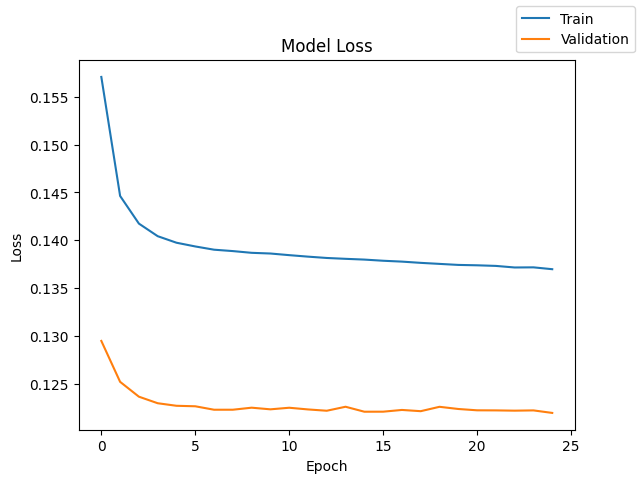

```python
plot(history,'loss')
```

```python
model_0_train_perf = model_performance_classification(model, x_train, y_train)
model_0_train_perf
```

```
250/250 ━━━━━━━━━━━━━━━━━━━━ 1s 3ms/step
```

|  | Accuracy | Recall | Precision | F1 Score |
| --- | --- | --- | --- | --- |
| 0 | 0.807625 | 0.807625 | 0.779839 | 0.748994 |

```python
model_0_valid_perf = model_performance_classification(model, x_val, y_val)
model_0_valid_perf
```

```
32/32 ━━━━━━━━━━━━━━━━━━━━ 0s 5ms/step
```

|  | Accuracy | Recall | Precision | F1 Score |
| --- | --- | --- | --- | --- |
| 0 | 0.834 | 0.834 | 0.815012 | 0.782367 |

```python
# Function for the chart
results.loc["Model 0"]=['-','-','-',epochs,batch_size,'SGD',(end-start),history.history["loss"][-1],history.history["val_loss"][-1]]
```

```python
# Displaying the results
results
```

|  | # hidden layers | # neurons - hidden layer | activation function - hidden layer | # epochs | batch size | optimizer | time(secs) | Train_loss | Valid_loss |
| --- | --- | --- | --- | --- | --- | --- | --- | --- | --- |
| Model 0 | - | - | - | 25 | 64 | SGD | 160.587798 | 0.136982 | 0.121964 |

- The train and validation recall scores being 0.81 and 0.83 indicate a relatively consistent performance, although the score isn't the best to have.
- The time taken is significantly longer due to the model parents being updated more often.
- The loss scores are relatively low as well, which is a good statistic.

## Model Performance Improvement

### Neural Network with Adam Optimizer

```python
# clears the current Keras session, resetting all layers and models previously created, freeing up memory and resources.
tf.keras.backend.clear_session()
```

```python
#Initializing the neural network
model = Sequential()
model.add(Dense(14,activation="relu",input_dim=x_train.shape[1]))
model.add(Dense(7,activation="relu"))
model.add(Dense(1,activation="sigmoid"))
```

```python
model.summary()
```

```
Model: "sequential"
```

```
┏━━━━━━━━━━━━━━━━━━━━━━━━━━━━━━━━━━━━━━┳━━━━━━━━━━━━━━━━━━━━━━━━━━━━━┳━━━━━━━━━━━━━━━━━┓
┃ Layer (type)                         ┃ Output Shape                ┃         Param # ┃
┡━━━━━━━━━━━━━━━━━━━━━━━━━━━━━━━━━━━━━━╇━━━━━━━━━━━━━━━━━━━━━━━━━━━━━╇━━━━━━━━━━━━━━━━━┩
│ dense (Dense)                        │ (None, 14)                  │          41,286 │
├──────────────────────────────────────┼─────────────────────────────┼─────────────────┤
│ dense_1 (Dense)                      │ (None, 7)                   │             105 │
├──────────────────────────────────────┼─────────────────────────────┼─────────────────┤
│ dense_2 (Dense)                      │ (None, 1)                   │               8 │
└──────────────────────────────────────┴─────────────────────────────┴─────────────────┘
```

```
 Total params: 41,399 (161.71 KB)
```

```
 Trainable params: 41,399 (161.71 KB)
```

```
 Non-trainable params: 0 (0.00 B)
```

```python
# Import the Adam optimizer from Keras
from tensorflow.keras.optimizers import Adam

optimizer = tf.keras.optimizers.Adam()    # defining Adam as the optimizer to be used
model.compile(loss='binary_crossentropy', optimizer=optimizer, metrics=metrics)
```

```python
start = time.time()
history = model.fit(x_train, y_train, validation_data=(x_val,y_val) , batch_size=batch_size, epochs=epochs)
end=time.time()
```

```
125/125 ━━━━━━━━━━━━━━━━━━━━ 3s 8ms/step - loss: 0.6196 - recall: 0.0381 - val_loss: 0.4141 - val_recall: 0.0000e+00
125/125 ━━━━━━━━━━━━━━━━━━━━ 1s 6ms/step - loss: 0.4188 - recall: 0.0571 - val_loss: 0.3698 - val_recall: 0.2570
125/125 ━━━━━━━━━━━━━━━━━━━━ 1s 8ms/step - loss: 0.3845 - recall: 0.3077 - val_loss: 0.3419 - val_recall: 0.3184
125/125 ━━━━━━━━━━━━━━━━━━━━ 1s 8ms/step - loss: 0.3377 - recall: 0.4204 - val_loss: 0.3295 - val_recall: 0.3799
125/125 ━━━━━━━━━━━━━━━━━━━━ 1s 7ms/step - loss: 0.3011 - recall: 0.5048 - val_loss: 0.3265 - val_recall: 0.4358
125/125 ━━━━━━━━━━━━━━━━━━━━ 1s 5ms/step - loss: 0.2736 - recall: 0.5936 - val_loss: 0.3354 - val_recall: 0.3855
125/125 ━━━━━━━━━━━━━━━━━━━━ 1s 5ms/step - loss: 0.2459 - recall: 0.6220 - val_loss: 0.3452 - val_recall: 0.4078
125/125 ━━━━━━━━━━━━━━━━━━━━ 1s 3ms/step - loss: 0.2228 - recall: 0.6932 - val_loss: 0.3660 - val_recall: 0.4413
125/125 ━━━━━━━━━━━━━━━━━━━━ 0s 3ms/step - loss: 0.2061 - recall: 0.7247 - val_loss: 0.3890 - val_recall: 0.5251
125/125 ━━━━━━━━━━━━━━━━━━━━ 1s 4ms/step - loss: 0.1894 - recall: 0.7642 - val_loss: 0.3991 - val_recall: 0.4637
125/125 ━━━━━━━━━━━━━━━━━━━━ 1s 5ms/step - loss: 0.1734 - recall: 0.7753 - val_loss: 0.4164 - val_recall: 0.4078
125/125 ━━━━━━━━━━━━━━━━━━━━ 1s 4ms/step - loss: 0.1632 - recall: 0.7989 - val_loss: 0.4382 - val_recall: 0.4134
125/125 ━━━━━━━━━━━━━━━━━━━━ 1s 5ms/step - loss: 0.1563 - recall: 0.8130 - val_loss: 0.4564 - val_recall: 0.4078
125/125 ━━━━━━━━━━━━━━━━━━━━ 1s 4ms/step - loss: 0.1403 - recall: 0.8240 - val_loss: 0.4712 - val_recall: 0.4134
125/125 ━━━━━━━━━━━━━━━━━━━━ 1s 4ms/step - loss: 0.1369 - recall: 0.8290 - val_loss: 0.4892 - val_recall: 0.4022
125/125 ━━━━━━━━━━━━━━━━━━━━ 1s 4ms/step - loss: 0.1278 - recall: 0.8434 - val_loss: 0.5210 - val_recall: 0.3799
125/125 ━━━━━━━━━━━━━━━━━━━━ 1s 5ms/step - loss: 0.1248 - recall: 0.8571 - val_loss: 0.5261 - val_recall: 0.4246
125/125 ━━━━━━━━━━━━━━━━━━━━ 1s 5ms/step - loss: 0.1196 - recall: 0.8540 - val_loss: 0.5478 - val_recall: 0.4358
125/125 ━━━━━━━━━━━━━━━━━━━━ 2s 8ms/step - loss: 0.1073 - recall: 0.8864 - val_loss: 0.5839 - val_recall: 0.3575
125/125 ━━━━━━━━━━━━━━━━━━━━ 1s 7ms/step - loss: 0.1031 - recall: 0.8728 - val_loss: 0.5857 - val_recall: 0.4860
125/125 ━━━━━━━━━━━━━━━━━━━━ 1s 6ms/step - loss: 0.1051 - recall: 0.8902 - val_loss: 0.6015 - val_recall: 0.3911
125/125 ━━━━━━━━━━━━━━━━━━━━ 1s 3ms/step - loss: 0.0971 - recall: 0.8925 - val_loss: 0.6261 - val_recall: 0.4022
125/125 ━━━━━━━━━━━━━━━━━━━━ 1s 4ms/step - loss: 0.0924 - recall: 0.8973 - val_loss: 0.6463 - val_recall: 0.3855
125/125 ━━━━━━━━━━━━━━━━━━━━ 1s 5ms/step - loss: 0.0879 - recall: 0.9180 - val_loss: 0.6545 - val_recall: 0.3855
125/125 ━━━━━━━━━━━━━━━━━━━━ 1s 5ms/step - loss: 0.0858 - recall: 0.9067 - val_loss: 0.6781 - val_recall: 0.3743
```

```python
print("Time taken in seconds ",end-start)
```

```
Time taken in seconds  25.44655203819275
```

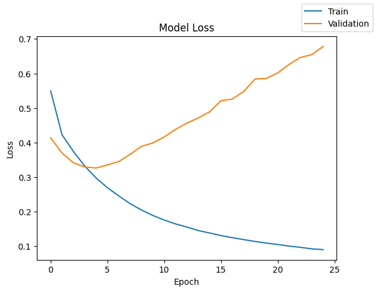

```python
plot(history,'loss')
```

```python
results.loc["Model 1"]=[2,[14,7],['relu','relu'],epochs,batch_size,'Adam',(end-start),history.history["loss"][-1],history.history["val_loss"][-1]]
```

```python
# Displaying the results
results
```

|  | # hidden layers | # neurons - hidden layer | activation function - hidden layer | # epochs | batch size | optimizer | time(secs) | Train_loss | Valid_loss |
| --- | --- | --- | --- | --- | --- | --- | --- | --- | --- |
| Model 0 | - | - | - | 25 | 64 | SGD | 160.587798 | 0.136982 | 0.121964 |
| Model 1 | 2 | [14, 7] | [relu, relu] | 25 | 64 | Adam | 25.446552 | 0.090293 | 0.678093 |

```python
model_1_train_perf = model_performance_classification(model, x_train, y_train)
model_1_train_perf
```

```
250/250 ━━━━━━━━━━━━━━━━━━━━ 1s 2ms/step
```

|  | Accuracy | Recall | Precision | F1 Score |
| --- | --- | --- | --- | --- |
| 0 | 0.972875 | 0.972875 | 0.972731 | 0.972518 |

```python
model_1_valid_perf = model_performance_classification(model, x_val, y_val)
model_1_valid_perf
```

```
32/32 ━━━━━━━━━━━━━━━━━━━━ 0s 3ms/step
```

|  | Accuracy | Recall | Precision | F1 Score |
| --- | --- | --- | --- | --- |
| 0 | 0.821 | 0.821 | 0.80432 | 0.81052 |

### Neural Network with Adam Optimizer and Dropout

```python
# clears the current Keras session, resetting all layers and models previously created, freeing up memory and resources.
tf.keras.backend.clear_session()
```

```python
import tensorflow as tf
from tensorflow.keras.models import Sequential
from tensorflow.keras.layers import Dense, Dropout
from tensorflow.keras.optimizers import Adam

# Define the model
model = Sequential()

# Input layer
model.add(Dense(64, activation='relu', input_shape=(2948,)))  # Adjust input_shape to match your feature count

# Hidden layer 1 with Dropout
model.add(Dense(128, activation='relu'))
model.add(Dropout(0.5))  # 50% dropout rate

# Hidden layer 2 with Dropout
model.add(Dense(64, activation='relu'))
model.add(Dropout(0.5))  # 50% dropout rate

# Output layer for binary classification
model.add(Dense(1, activation='sigmoid'))
```

```python
model.summary()
```

```
Model: "sequential"
```

```
┏━━━━━━━━━━━━━━━━━━━━━━━━━━━━━━━━━━━━━━┳━━━━━━━━━━━━━━━━━━━━━━━━━━━━━┳━━━━━━━━━━━━━━━━━┓
┃ Layer (type)                         ┃ Output Shape                ┃         Param # ┃
┡━━━━━━━━━━━━━━━━━━━━━━━━━━━━━━━━━━━━━━╇━━━━━━━━━━━━━━━━━━━━━━━━━━━━━╇━━━━━━━━━━━━━━━━━┩
│ dense (Dense)                        │ (None, 64)                  │         188,736 │
├──────────────────────────────────────┼─────────────────────────────┼─────────────────┤
│ dense_1 (Dense)                      │ (None, 128)                 │           8,320 │
├──────────────────────────────────────┼─────────────────────────────┼─────────────────┤
│ dropout (Dropout)                    │ (None, 128)                 │               0 │
├──────────────────────────────────────┼─────────────────────────────┼─────────────────┤
│ dense_2 (Dense)                      │ (None, 64)                  │           8,256 │
├──────────────────────────────────────┼─────────────────────────────┼─────────────────┤
│ dropout_1 (Dropout)                  │ (None, 64)                  │               0 │
├──────────────────────────────────────┼─────────────────────────────┼─────────────────┤
│ dense_3 (Dense)                      │ (None, 1)                   │              65 │
└──────────────────────────────────────┴─────────────────────────────┴─────────────────┘
```

```
 Total params: 205,377 (802.25 KB)
```

```
 Trainable params: 205,377 (802.25 KB)
```

```
 Non-trainable params: 0 (0.00 B)
```

```python
# Compile the model with Adam optimizer and binary cross-entropy loss
model.compile(optimizer=Adam(learning_rate=0.001),
              loss='binary_crossentropy',
              metrics=[tf.keras.metrics.Recall(name="recall")])
```

```python
start = time.time()
history = model.fit(x_train, y_train, validation_data=(x_val,y_val) , batch_size=batch_size, epochs=epochs)
end=time.time()
```

```
125/125 ━━━━━━━━━━━━━━━━━━━━ 2s 8ms/step - loss: 0.5549 - recall: 0.0812 - val_loss: 0.3841 - val_recall: 0.0000e+00
125/125 ━━━━━━━━━━━━━━━━━━━━ 1s 5ms/step - loss: 0.4070 - recall: 0.0879 - val_loss: 0.3470 - val_recall: 0.3855
125/125 ━━━━━━━━━━━━━━━━━━━━ 2s 9ms/step - loss: 0.3346 - recall: 0.4751 - val_loss: 0.3457 - val_recall: 0.5475
125/125 ━━━━━━━━━━━━━━━━━━━━ 1s 12ms/step - loss: 0.2494 - recall: 0.6810 - val_loss: 0.3937 - val_recall: 0.4358
125/125 ━━━━━━━━━━━━━━━━━━━━ 2s 13ms/step - loss: 0.1831 - recall: 0.8085 - val_loss: 0.4646 - val_recall: 0.4581
125/125 ━━━━━━━━━━━━━━━━━━━━ 2s 7ms/step - loss: 0.1339 - recall: 0.8560 - val_loss: 0.5453 - val_recall: 0.4413
125/125 ━━━━━━━━━━━━━━━━━━━━ 2s 9ms/step - loss: 0.0802 - recall: 0.9152 - val_loss: 0.6431 - val_recall: 0.4134
125/125 ━━━━━━━━━━━━━━━━━━━━ 1s 7ms/step - loss: 0.0661 - recall: 0.9283 - val_loss: 0.7643 - val_recall: 0.4134
125/125 ━━━━━━━━━━━━━━━━━━━━ 1s 8ms/step - loss: 0.0516 - recall: 0.9454 - val_loss: 0.8802 - val_recall: 0.3966
125/125 ━━━━━━━━━━━━━━━━━━━━ 1s 10ms/step - loss: 0.0420 - recall: 0.9558 - val_loss: 0.8875 - val_recall: 0.3408
125/125 ━━━━━━━━━━━━━━━━━━━━ 3s 10ms/step - loss: 0.0203 - recall: 0.9742 - val_loss: 1.0600 - val_recall: 0.3687
125/125 ━━━━━━━━━━━━━━━━━━━━ 1s 9ms/step - loss: 0.0239 - recall: 0.9730 - val_loss: 1.0307 - val_recall: 0.4469
125/125 ━━━━━━━━━━━━━━━━━━━━ 2s 13ms/step - loss: 0.0165 - recall: 0.9853 - val_loss: 1.2330 - val_recall: 0.5084
125/125 ━━━━━━━━━━━━━━━━━━━━ 3s 14ms/step - loss: 0.0211 - recall: 0.9871 - val_loss: 1.2006 - val_recall: 0.3911
125/125 ━━━━━━━━━━━━━━━━━━━━ 2s 9ms/step - loss: 0.0065 - recall: 0.9915 - val_loss: 1.3172 - val_recall: 0.3687
125/125 ━━━━━━━━━━━━━━━━━━━━ 1s 7ms/step - loss: 0.0133 - recall: 0.9907 - val_loss: 1.3429 - val_recall: 0.4134
125/125 ━━━━━━━━━━━━━━━━━━━━ 1s 6ms/step - loss: 0.0085 - recall: 0.9949 - val_loss: 1.4209 - val_recall: 0.4358
125/125 ━━━━━━━━━━━━━━━━━━━━ 1s 8ms/step - loss: 0.0138 - recall: 0.9884 - val_loss: 1.3985 - val_recall: 0.4246
125/125 ━━━━━━━━━━━━━━━━━━━━ 1s 9ms/step - loss: 0.0052 - recall: 0.9946 - val_loss: 1.4374 - val_recall: 0.3855
125/125 ━━━━━━━━━━━━━━━━━━━━ 1s 8ms/step - loss: 0.0130 - recall: 0.9899 - val_loss: 1.3727 - val_recall: 0.4078
125/125 ━━━━━━━━━━━━━━━━━━━━ 1s 6ms/step - loss: 0.0072 - recall: 0.9926 - val_loss: 1.4525 - val_recall: 0.3240
125/125 ━━━━━━━━━━━━━━━━━━━━ 2s 10ms/step - loss: 0.0072 - recall: 0.9932 - val_loss: 1.3668 - val_recall: 0.4190
125/125 ━━━━━━━━━━━━━━━━━━━━ 3s 13ms/step - loss: 0.0048 - recall: 0.9962 - val_loss: 1.4630 - val_recall: 0.3966
125/125 ━━━━━━━━━━━━━━━━━━━━ 2s 10ms/step - loss: 0.0151 - recall: 0.9875 - val_loss: 1.4375 - val_recall: 0.4190
125/125 ━━━━━━━━━━━━━━━━━━━━ 1s 6ms/step - loss: 0.0047 - recall: 0.9940 - val_loss: 1.5045 - val_recall: 0.3855
```

```python
print("Time taken in seconds ",end-start)
```

```
Time taken in seconds  40.763280630111694
```

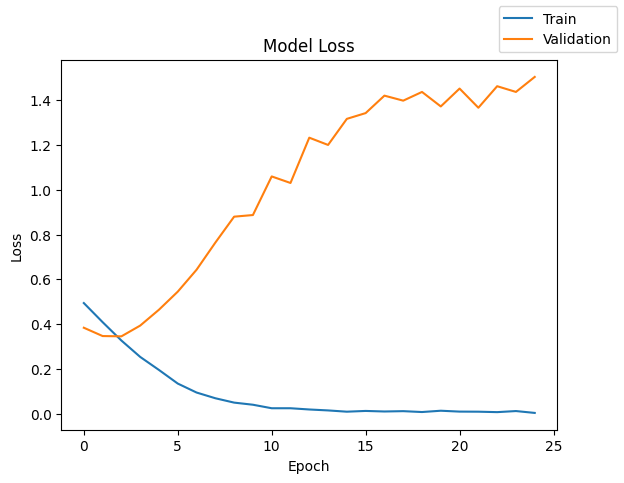

```python
plot(history,'loss')
```

```python
# Function for the chart

results.loc["Model 2"]=[3,[64,128,64],['relu','relu','relu'],epochs,batch_size,'Adam',(end-start),history.history["loss"][-1],history.history["val_loss"][-1]]
```

```python
# Displaying the results
results
```

|  | # hidden layers | # neurons - hidden layer | activation function - hidden layer | # epochs | batch size | optimizer | time(secs) | Train_loss | Valid_loss |
| --- | --- | --- | --- | --- | --- | --- | --- | --- | --- |
| Model 0 | - | - | - | 25 | 64 | SGD | 160.587798 | 0.136982 | 0.121964 |
| Model 1 | 2 | [14, 7] | [relu, relu] | 25 | 64 | Adam | 25.446552 | 0.090293 | 0.678093 |
| Model 2 | 3 | [64, 128, 64] | [relu, relu, relu] | 25 | 64 | Adam | 40.763281 | 0.003548 | 1.504508 |

```python
model_2_train_perf = model_performance_classification(model, x_train, y_train)
model_2_train_perf
```

```
250/250 ━━━━━━━━━━━━━━━━━━━━ 1s 2ms/step
```

|  | Accuracy | Recall | Precision | F1 Score |
| --- | --- | --- | --- | --- |
| 0 | 1.0 | 1.0 | 1.0 | 1.0 |

```python
model_2_valid_perf = model_performance_classification(model, x_val, y_val)
model_2_valid_perf
```

```
32/32 ━━━━━━━━━━━━━━━━━━━━ 0s 4ms/step
```

|  | Accuracy | Recall | Precision | F1 Score |
| --- | --- | --- | --- | --- |
| 0 | 0.808 | 0.808 | 0.796422 | 0.801464 |

### Neural Network with Balanced Data (by applying SMOTE) and SGD Optimizer

```python
tf.keras.backend.clear_session()
```

```python
# Import the SMOTE class from imblearn.over_sampling
from imblearn.over_sampling import SMOTE

# Apply SMOTE to balance the training data
smote = SMOTE(random_state=42)
x_train_smote, y_train_smote = smote.fit_resample(x_train, y_train)

# Further split the balanced training set into training and validation sets
x_train_smote, x_val, y_train_smote, y_val = train_test_split(x_train_smote, y_train_smote, test_size=0.2, random_state=42)
```

```python
# Standardize the data
scaler = StandardScaler()
x_train_smote = scaler.fit_transform(x_train_smote)
x_val = scaler.transform(x_val)
x_test = scaler.transform(x_test)
```

```python
# Define the model
model = Sequential()

# Input layer
model.add(Dense(64, activation='relu', input_shape=(x_train_smote.shape[1],)))  # Number of features

# Hidden layers
model.add(Dense(128, activation='relu'))
model.add(Dense(64, activation='relu'))

# Output layer
model.add(Dense(1, activation='sigmoid'))
```

```python
# Compile the model with SGD optimizer
model.compile(optimizer=SGD(learning_rate=0.01),
              loss='binary_crossentropy',
              metrics=[tf.keras.metrics.Recall(name='recall')])
```

```python
start = time.time()
history = model.fit(x_train_smote, y_train_smote, validation_data=(x_val, y_val), epochs=epochs, batch_size=batch_size)
end=time.time()
```

```
160/160 ━━━━━━━━━━━━━━━━━━━━ 4s 17ms/step - loss: 0.6099 - recall: 0.3944 - val_loss: 0.5860 - val_recall: 0.7873
160/160 ━━━━━━━━━━━━━━━━━━━━ 2s 9ms/step - loss: 0.5392 - recall: 0.7403 - val_loss: 0.5551 - val_recall: 0.7889
160/160 ━━━━━━━━━━━━━━━━━━━━ 1s 8ms/step - loss: 0.4819 - recall: 0.7433 - val_loss: 0.5373 - val_recall: 0.8022
160/160 ━━━━━━━━━━━━━━━━━━━━ 2s 6ms/step - loss: 0.4229 - recall: 0.7586 - val_loss: 0.5273 - val_recall: 0.8053
160/160 ━━━━━━━━━━━━━━━━━━━━ 1s 7ms/step - loss: 0.3705 - recall: 0.7773 - val_loss: 0.5273 - val_recall: 0.8093
160/160 ━━━━━━━━━━━━━━━━━━━━ 1s 7ms/step - loss: 0.3175 - recall: 0.7957 - val_loss: 0.5390 - val_recall: 0.8124
160/160 ━━━━━━━━━━━━━━━━━━━━ 1s 6ms/step - loss: 0.2720 - recall: 0.8173 - val_loss: 0.5629 - val_recall: 0.8171
160/160 ━━━━━━━━━━━━━━━━━━━━ 1s 7ms/step - loss: 0.2360 - recall: 0.8508 - val_loss: 0.5896 - val_recall: 0.8148
160/160 ━━━━━━━━━━━━━━━━━━━━ 1s 4ms/step - loss: 0.2159 - recall: 0.8524 - val_loss: 0.6186 - val_recall: 0.8210
160/160 ━━━━━━━━━━━━━━━━━━━━ 2s 11ms/step - loss: 0.2108 - recall: 0.8598 - val_loss: 0.6475 - val_recall: 0.8210
160/160 ━━━━━━━━━━━━━━━━━━━━ 2s 10ms/step - loss: 0.1923 - recall: 0.8726 - val_loss: 0.6722 - val_recall: 0.8305
160/160 ━━━━━━━━━━━━━━━━━━━━ 2s 10ms/step - loss: 0.1834 - recall: 0.8829 - val_loss: 0.6917 - val_recall: 0.8281
160/160 ━━━━━━━━━━━━━━━━━━━━ 1s 8ms/step - loss: 0.1816 - recall: 0.8830 - val_loss: 0.7121 - val_recall: 0.8336
160/160 ━━━━━━━━━━━━━━━━━━━━ 2s 4ms/step - loss: 0.1859 - recall: 0.8769 - val_loss: 0.7277 - val_recall: 0.8367
160/160 ━━━━━━━━━━━━━━━━━━━━ 1s 5ms/step - loss: 0.1765 - recall: 0.8805 - val_loss: 0.7454 - val_recall: 0.8352
160/160 ━━━━━━━━━━━━━━━━━━━━ 1s 4ms/step - loss: 0.1701 - recall: 0.8893 - val_loss: 0.7620 - val_recall: 0.8430
160/160 ━━━━━━━━━━━━━━━━━━━━ 1s 5ms/step - loss: 0.1752 - recall: 0.8929 - val_loss: 0.7753 - val_recall: 0.8407
160/160 ━━━━━━━━━━━━━━━━━━━━ 1s 4ms/step - loss: 0.1647 - recall: 0.8959 - val_loss: 0.7829 - val_recall: 0.8422
160/160 ━━━━━━━━━━━━━━━━━━━━ 1s 4ms/step - loss: 0.1619 - recall: 0.9000 - val_loss: 0.7944 - val_recall: 0.8399
160/160 ━━━━━━━━━━━━━━━━━━━━ 1s 4ms/step - loss: 0.1589 - recall: 0.8960 - val_loss: 0.8038 - val_recall: 0.8375
160/160 ━━━━━━━━━━━━━━━━━━━━ 1s 4ms/step - loss: 0.1553 - recall: 0.9001 - val_loss: 0.8179 - val_recall: 0.8493
160/160 ━━━━━━━━━━━━━━━━━━━━ 1s 4ms/step - loss: 0.1569 - recall: 0.9015 - val_loss: 0.8196 - val_recall: 0.8446
160/160 ━━━━━━━━━━━━━━━━━━━━ 2s 7ms/step - loss: 0.1585 - recall: 0.8983 - val_loss: 0.8329 - val_recall: 0.8430
160/160 ━━━━━━━━━━━━━━━━━━━━ 2s 9ms/step - loss: 0.1508 - recall: 0.9091 - val_loss: 0.8390 - val_recall: 0.8367
160/160 ━━━━━━━━━━━━━━━━━━━━ 2s 8ms/step - loss: 0.1550 - recall: 0.9006 - val_loss: 0.8505 - val_recall: 0.8391
```

```python
print("Time taken in seconds ",end-start)
```

```
Time taken in seconds  37.55686664581299
```

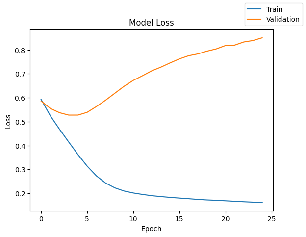

```python
plot(history,'loss')
```

```python
# Function for the chart

results.loc["Model 3"]=[3,[64,128,64],['relu','relu','relu'],epochs,batch_size,'SGD + SMOTE',(end-start),history.history["loss"][-1],history.history["val_loss"][-1]]
```

```python
# Display the chart
results
```

|  | # hidden layers | # neurons - hidden layer | activation function - hidden layer | # epochs | batch size | optimizer | time(secs) | Train_loss | Valid_loss |
| --- | --- | --- | --- | --- | --- | --- | --- | --- | --- |
| Model 0 | - | - | - | 25 | 64 | SGD | 160.587798 | 0.136982 | 0.121964 |
| Model 1 | 2 | [14, 7] | [relu, relu] | 25 | 64 | Adam | 25.446552 | 0.090293 | 0.678093 |
| Model 2 | 3 | [64, 128, 64] | [relu, relu, relu] | 25 | 64 | Adam | 40.763281 | 0.003548 | 1.504508 |
| Model 3 | 3 | [64, 128, 64] | [relu, relu, relu] | 25 | 64 | SGD + SMOTE | 37.556867 | 0.161548 | 0.850490 |

```python
model_3_train_perf = model_performance_classification(model, x_train_smote, y_train_smote)
model_3_train_perf
```

```
319/319 ━━━━━━━━━━━━━━━━━━━━ 1s 3ms/step
```

|  | Accuracy | Recall | Precision | F1 Score |
| --- | --- | --- | --- | --- |
| 0 | 0.940612 | 0.940612 | 0.942162 | 0.94056 |

```python
model_3_valid_perf = model_performance_classification(model, x_val, y_val)
model_3_valid_perf
```

```
80/80 ━━━━━━━━━━━━━━━━━━━━ 0s 2ms/step
```

|  | Accuracy | Recall | Precision | F1 Score |
| --- | --- | --- | --- | --- |
| 0 | 0.766066 | 0.766066 | 0.771958 | 0.76483 |

### Neural Network with Balanced Data (by applying SMOTE) and Adam Optimizer

```python
tf.keras.backend.clear_session()
```

```python
# Split data into training and validation sets
x_train, x_val, y_train, y_val = train_test_split(X, y, test_size=0.2, random_state=42)

# Apply SMOTE to balance the training data
smote = SMOTE(random_state=42)
x_train_smote, y_train_smote = smote.fit_resample(x_train, y_train)
```

```python
import tensorflow as tf
from tensorflow.keras.models import Sequential
from tensorflow.keras.layers import Dense, Dropout

# Standardize the data
scaler = StandardScaler()
x_train_smote = scaler.fit_transform(x_train_smote)
x_val = scaler.transform(x_val)

# Define the model
model = Sequential()
model.add(Dense(64, activation='relu', input_shape=(x_train_smote.shape[1],)))  # Input layer
model.add(Dense(128, activation='relu'))  # Hidden layer 1
model.add(Dense(64, activation='relu'))  # Hidden layer 2
model.add(Dense(1, activation='sigmoid'))  # Output layer for binary classification

# Compile the model with Adam optimizer and recall as a metric
model.compile(optimizer='adam',
              loss='binary_crossentropy',
              metrics=[tf.keras.metrics.Recall(name='recall')])
```

```python
start = time.time()
history = model.fit(x_train_smote, y_train_smote, validation_data=(x_val, y_val), epochs=epochs, batch_size=batch_size)
end=time.time()
```

```
199/199 ━━━━━━━━━━━━━━━━━━━━ 3s 7ms/step - loss: 0.4553 - recall: 0.6847 - val_loss: 0.9000 - val_recall: 0.1781
199/199 ━━━━━━━━━━━━━━━━━━━━ 2s 10ms/step - loss: 0.2597 - recall: 0.7762 - val_loss: 0.9675 - val_recall: 0.2926
199/199 ━━━━━━━━━━━━━━━━━━━━ 2s 10ms/step - loss: 0.2220 - recall: 0.8396 - val_loss: 0.9845 - val_recall: 0.3104
199/199 ━━━━━━━━━━━━━━━━━━━━ 2s 7ms/step - loss: 0.1995 - recall: 0.8579 - val_loss: 1.0382 - val_recall: 0.2824
199/199 ━━━━━━━━━━━━━━━━━━━━ 2s 5ms/step - loss: 0.1760 - recall: 0.8706 - val_loss: 1.0837 - val_recall: 0.3435
199/199 ━━━━━━━━━━━━━━━━━━━━ 1s 6ms/step - loss: 0.1645 - recall: 0.8827 - val_loss: 1.1163 - val_recall: 0.3181
199/199 ━━━━━━━━━━━━━━━━━━━━ 1s 5ms/step - loss: 0.1497 - recall: 0.8898 - val_loss: 1.3353 - val_recall: 0.3842
199/199 ━━━━━━━━━━━━━━━━━━━━ 1s 6ms/step - loss: 0.1392 - recall: 0.8962 - val_loss: 1.2558 - val_recall: 0.3461
199/199 ━━━━━━━━━━━━━━━━━━━━ 1s 6ms/step - loss: 0.1303 - recall: 0.8982 - val_loss: 1.5180 - val_recall: 0.4097
199/199 ━━━━━━━━━━━━━━━━━━━━ 1s 6ms/step - loss: 0.1145 - recall: 0.9139 - val_loss: 1.3861 - val_recall: 0.3639
199/199 ━━━━━━━━━━━━━━━━━━━━ 2s 8ms/step - loss: 0.0955 - recall: 0.9312 - val_loss: 1.4466 - val_recall: 0.4122
199/199 ━━━━━━━━━━━━━━━━━━━━ 3s 10ms/step - loss: 0.0834 - recall: 0.9450 - val_loss: 1.7693 - val_recall: 0.4046
199/199 ━━━━━━━━━━━━━━━━━━━━ 2s 5ms/step - loss: 0.0671 - recall: 0.9595 - val_loss: 1.9841 - val_recall: 0.4275
199/199 ━━━━━━━━━━━━━━━━━━━━ 1s 5ms/step - loss: 0.0539 - recall: 0.9695 - val_loss: 2.0981 - val_recall: 0.4249
199/199 ━━━━━━━━━━━━━━━━━━━━ 1s 6ms/step - loss: 0.0390 - recall: 0.9819 - val_loss: 2.3223 - val_recall: 0.4198
199/199 ━━━━━━━━━━━━━━━━━━━━ 1s 6ms/step - loss: 0.0307 - recall: 0.9855 - val_loss: 2.4590 - val_recall: 0.4326
199/199 ━━━━━━━━━━━━━━━━━━━━ 1s 6ms/step - loss: 0.0208 - recall: 0.9906 - val_loss: 2.6391 - val_recall: 0.4529
199/199 ━━━━━━━━━━━━━━━━━━━━ 1s 6ms/step - loss: 0.0166 - recall: 0.9938 - val_loss: 2.9496 - val_recall: 0.4427
199/199 ━━━━━━━━━━━━━━━━━━━━ 1s 6ms/step - loss: 0.0122 - recall: 0.9950 - val_loss: 3.1670 - val_recall: 0.4733
199/199 ━━━━━━━━━━━━━━━━━━━━ 1s 6ms/step - loss: 0.0150 - recall: 0.9963 - val_loss: 3.2079 - val_recall: 0.4351
199/199 ━━━━━━━━━━━━━━━━━━━━ 2s 9ms/step - loss: 0.0095 - recall: 0.9952 - val_loss: 3.3593 - val_recall: 0.4402
199/199 ━━━━━━━━━━━━━━━━━━━━ 2s 8ms/step - loss: 0.0112 - recall: 0.9965 - val_loss: 3.0912 - val_recall: 0.4555
199/199 ━━━━━━━━━━━━━━━━━━━━ 1s 5ms/step - loss: 0.0056 - recall: 0.9981 - val_loss: 3.2425 - val_recall: 0.4580
199/199 ━━━━━━━━━━━━━━━━━━━━ 1s 6ms/step - loss: 0.0054 - recall: 0.9985 - val_loss: 3.1998 - val_recall: 0.4300
199/199 ━━━━━━━━━━━━━━━━━━━━ 1s 5ms/step - loss: 0.0045 - recall: 0.9979 - val_loss: 3.6766 - val_recall: 0.5089
```

```python
print("Time taken in seconds ",end-start)
```

```
Time taken in seconds  40.7591872215271
```

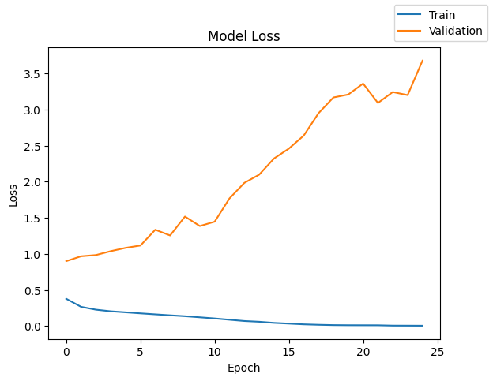

```python
plot(history,'loss')
```

```python
# Function for the chart

results.loc["Model 4"]=[3,[64,128,64],['relu','relu','relu'],epochs,batch_size,'Adam + SMOTE',(end-start),history.history["loss"][-1],history.history["val_loss"][-1]]
```

```python
# Displaying the results
results
```

|  | # hidden layers | # neurons - hidden layer | activation function - hidden layer | # epochs | batch size | optimizer | time(secs) | Train_loss | Valid_loss |
| --- | --- | --- | --- | --- | --- | --- | --- | --- | --- |
| Model 0 | - | - | - | 25 | 64 | SGD | 160.587798 | 0.136982 | 0.121964 |
| Model 1 | 2 | [14, 7] | [relu, relu] | 25 | 64 | Adam | 25.446552 | 0.090293 | 0.678093 |
| Model 2 | 3 | [64, 128, 64] | [relu, relu, relu] | 25 | 64 | Adam | 40.763281 | 0.003548 | 1.504508 |
| Model 3 | 3 | [64, 128, 64] | [relu, relu, relu] | 25 | 64 | SGD + SMOTE | 37.556867 | 0.161548 | 0.850490 |
| Model 4 | 3 | [64, 128, 64] | [relu, relu, relu] | 25 | 64 | Adam + SMOTE | 40.759187 | 0.005454 | 3.676630 |

```python
model_4_train_perf = model_performance_classification(model, x_train_smote, y_train_smote)
model_4_train_perf
```

```
398/398 ━━━━━━━━━━━━━━━━━━━━ 1s 2ms/step
```

|  | Accuracy | Recall | Precision | F1 Score |
| --- | --- | --- | --- | --- |
| 0 | 0.998584 | 0.998584 | 0.998585 | 0.998584 |

```python
model_4_valid_perf = model_performance_classification(model, x_val, y_val)
model_4_valid_perf
```

```
63/63 ━━━━━━━━━━━━━━━━━━━━ 0s 2ms/step
```

|  | Accuracy | Recall | Precision | F1 Score |
| --- | --- | --- | --- | --- |
| 0 | 0.662 | 0.662 | 0.743291 | 0.690787 |

### Neural Network with Balanced Data (by applying SMOTE), Adam Optimizer, and Dropout

```python
tf.keras.backend.clear_session()
```

```python
from imblearn.over_sampling import SMOTE
from sklearn.model_selection import train_test_split

# Applying SMOTE to balance the data
smote = SMOTE()
x_smote, y_smote = smote.fit_resample(x_train, y_train)

# Split the SMOTE balanced data into training and validation sets
x_train_smote, x_val, y_train_smote, y_val = train_test_split(x_smote, y_smote, test_size=0.2, random_state=42)
```

```python
from tensorflow.keras.models import Sequential
from tensorflow.keras.layers import Dense, Dropout
from tensorflow.keras.optimizers import Adam

# Initialize the neural network
model = Sequential()

# Input layer
model.add(Dense(64, activation='relu', input_dim=x_train_smote.shape[1]))

# Hidden layer 1 with Dropout
model.add(Dense(128, activation='relu'))
model.add(Dropout(0.5))  # 50% dropout rate

# Hidden layer 2 with Dropout
model.add(Dense(64, activation='relu'))
model.add(Dropout(0.5))  # 50% dropout rate

# Output layer for binary classification
model.add(Dense(1, activation='sigmoid'))

# Compile the model with Adam optimizer and Recall metric
model.compile(optimizer=Adam(learning_rate=0.001), loss='binary_crossentropy', metrics=['Recall'])
```

```python
start = time.time()
history = model.fit(x_train_smote, y_train_smote, validation_data=(x_val, y_val), epochs=epochs, batch_size=batch_size)
end=time.time()
```

```
159/159 ━━━━━━━━━━━━━━━━━━━━ 4s 11ms/step - Recall: 0.5545 - loss: 342.2238 - val_Recall: 0.4298 - val_loss: 1.2335
159/159 ━━━━━━━━━━━━━━━━━━━━ 2s 6ms/step - Recall: 0.5327 - loss: 8.9537 - val_Recall: 0.7008 - val_loss: 0.6970
159/159 ━━━━━━━━━━━━━━━━━━━━ 1s 7ms/step - Recall: 0.4163 - loss: 3.0170 - val_Recall: 0.0105 - val_loss: 0.6961
159/159 ━━━━━━━━━━━━━━━━━━━━ 1s 7ms/step - Recall: 0.0148 - loss: 0.7071 - val_Recall: 0.0129 - val_loss: 0.6942
159/159 ━━━━━━━━━━━━━━━━━━━━ 1s 6ms/step - Recall: 0.0024 - loss: 0.6933 - val_Recall: 0.0000e+00 - val_loss: 0.6929
159/159 ━━━━━━━━━━━━━━━━━━━━ 1s 7ms/step - Recall: 2.7224e-05 - loss: 0.6933 - val_Recall: 0.0000e+00 - val_loss: 0.6931
159/159 ━━━━━━━━━━━━━━━━━━━━ 1s 6ms/step - Recall: 0.1783 - loss: 0.6931 - val_Recall: 0.9984 - val_loss: 0.6931
159/159 ━━━━━━━━━━━━━━━━━━━━ 1s 6ms/step - Recall: 0.9329 - loss: 0.6931 - val_Recall: 0.9976 - val_loss: 0.6931
159/159 ━━━━━━━━━━━━━━━━━━━━ 1s 9ms/step - Recall: 0.9983 - loss: 0.6932 - val_Recall: 0.9984 - val_loss: 0.6931
159/159 ━━━━━━━━━━━━━━━━━━━━ 2s 10ms/step - Recall: 0.9990 - loss: 0.6931 - val_Recall: 0.9984 - val_loss: 0.6930
159/159 ━━━━━━━━━━━━━━━━━━━━ 2s 10ms/step - Recall: 0.9979 - loss: 0.6931 - val_Recall: 0.9992 - val_loss: 0.6929
159/159 ━━━━━━━━━━━━━━━━━━━━ 1s 8ms/step - Recall: 0.9977 - loss: 0.6931 - val_Recall: 0.9992 - val_loss: 0.6926
159/159 ━━━━━━━━━━━━━━━━━━━━ 1s 7ms/step - Recall: 0.9972 - loss: 0.6949 - val_Recall: 1.0000 - val_loss: 0.6929
159/159 ━━━━━━━━━━━━━━━━━━━━ 1s 6ms/step - Recall: 0.9884 - loss: 0.6972 - val_Recall: 1.0000 - val_loss: 0.6926
159/159 ━━━━━━━━━━━━━━━━━━━━ 1s 6ms/step - Recall: 1.0000 - loss: 0.6930 - val_Recall: 1.0000 - val_loss: 0.6925
159/159 ━━━━━━━━━━━━━━━━━━━━ 1s 6ms/step - Recall: 0.9745 - loss: 0.6925 - val_Recall: 1.0000 - val_loss: 0.6924
159/159 ━━━━━━━━━━━━━━━━━━━━ 1s 7ms/step - Recall: 0.9998 - loss: 0.6926 - val_Recall: 1.0000 - val_loss: 0.6923
159/159 ━━━━━━━━━━━━━━━━━━━━ 1s 6ms/step - Recall: 0.9993 - loss: 0.6928 - val_Recall: 1.0000 - val_loss: 0.6922
159/159 ━━━━━━━━━━━━━━━━━━━━ 1s 6ms/step - Recall: 0.9990 - loss: 0.6929 - val_Recall: 1.0000 - val_loss: 0.6923
159/159 ━━━━━━━━━━━━━━━━━━━━ 2s 9ms/step - Recall: 0.9993 - loss: 0.6927 - val_Recall: 1.0000 - val_loss: 0.6922
159/159 ━━━━━━━━━━━━━━━━━━━━ 2s 10ms/step - Recall: 0.9997 - loss: 0.6929 - val_Recall: 0.9984 - val_loss: 0.6918
159/159 ━━━━━━━━━━━━━━━━━━━━ 2s 8ms/step - Recall: 0.9854 - loss: 0.7353 - val_Recall: 0.9702 - val_loss: 0.6919
159/159 ━━━━━━━━━━━━━━━━━━━━ 1s 6ms/step - Recall: 0.9968 - loss: 0.6939 - val_Recall: 0.9992 - val_loss: 0.6920
159/159 ━━━━━━━━━━━━━━━━━━━━ 1s 7ms/step - Recall: 0.9994 - loss: 0.6924 - val_Recall: 0.9992 - val_loss: 0.6920
159/159 ━━━━━━━━━━━━━━━━━━━━ 1s 7ms/step - Recall: 0.9996 - loss: 0.6924 - val_Recall: 0.9992 - val_loss: 0.6920
```

```python
print("Time taken in seconds ",end-start)
```

```
Time taken in seconds  37.589741945266724
```

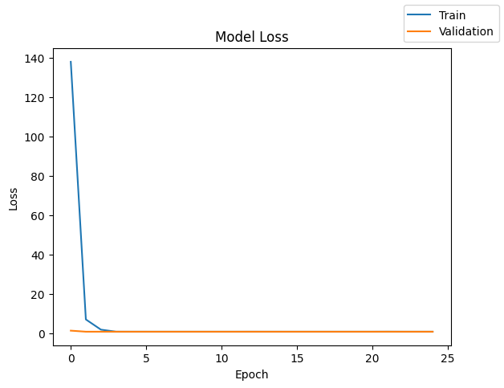

```python
plot(history,'loss')
```

```python
# Function for the chart

results.loc["Model 5"]=[2,[128,64],['relu','relu'],epochs,batch_size,'Adam + SMOTE',(end-start),history.history["loss"][-1],history.history["val_loss"][-1]]
```

```python
# Displaying the results
results
```

|  | # hidden layers | # neurons - hidden layer | activation function - hidden layer | # epochs | batch size | optimizer | time(secs) | Train_loss | Valid_loss |
| --- | --- | --- | --- | --- | --- | --- | --- | --- | --- |
| Model 0 | - | - | - | 25 | 64 | SGD | 160.587798 | 0.136982 | 0.121964 |
| Model 1 | 2 | [14, 7] | [relu, relu] | 25 | 64 | Adam | 25.446552 | 0.090293 | 0.678093 |
| Model 2 | 3 | [64, 128, 64] | [relu, relu, relu] | 25 | 64 | Adam | 40.763281 | 0.003548 | 1.504508 |
| Model 3 | 3 | [64, 128, 64] | [relu, relu, relu] | 25 | 64 | SGD + SMOTE | 37.556867 | 0.161548 | 0.850490 |
| Model 4 | 3 | [64, 128, 64] | [relu, relu, relu] | 25 | 64 | Adam + SMOTE | 40.759187 | 0.005454 | 3.676630 |
| Model 5 | 2 | [128, 64] | [relu, relu] | 25 | 64 | Adam + SMOTE | 37.589742 | 0.692641 | 0.691960 |

```python
model_5_train_perf = model_performance_classification(model, x_train_smote, y_train_smote)
model_5_train_perf
```

```
318/318 ━━━━━━━━━━━━━━━━━━━━ 1s 4ms/step
```

|  | Accuracy | Recall | Precision | F1 Score |
| --- | --- | --- | --- | --- |
| 0 | 0.503688 | 0.503688 | 0.576246 | 0.339307 |

```python
model_5_valid_perf = model_performance_classification(model, x_val, y_val)
model_5_valid_perf
```

```
80/80 ━━━━━━━━━━━━━━━━━━━━ 0s 2ms/step
```

|  | Accuracy | Recall | Precision | F1 Score |
| --- | --- | --- | --- | --- |
| 0 | 0.490366 | 0.490366 | 0.693874 | 0.326414 |

- In the final Model 5, it can be observed that the recall score stands out over all the other models. For it is the lowest overall for both training and validation data sets. However, it is generalized enough compared to the others which are not closely generalized at all.
- The time taken to run through all the epochs in this model is one of the lowest.
- From the recall scores being generalized, the training and validation loss scores are also balanced as well.

## Model Performance Comparison and Final Model Selection

```python
# Displaying the reults for all the models
results
```

|  | # hidden layers | # neurons - hidden layer | activation function - hidden layer | # epochs | batch size | optimizer | time(secs) | Train_loss | Valid_loss |
| --- | --- | --- | --- | --- | --- | --- | --- | --- | --- |
| Model 0 | - | - | - | 25 | 64 | SGD | 160.587798 | 0.136982 | 0.121964 |
| Model 1 | 2 | [14, 7] | [relu, relu] | 25 | 64 | Adam | 25.446552 | 0.090293 | 0.678093 |
| Model 2 | 3 | [64, 128, 64] | [relu, relu, relu] | 25 | 64 | Adam | 40.763281 | 0.003548 | 1.504508 |
| Model 3 | 3 | [64, 128, 64] | [relu, relu, relu] | 25 | 64 | SGD + SMOTE | 37.556867 | 0.161548 | 0.850490 |
| Model 4 | 3 | [64, 128, 64] | [relu, relu, relu] | 25 | 64 | Adam + SMOTE | 40.759187 | 0.005454 | 3.676630 |
| Model 5 | 2 | [128, 64] | [relu, relu] | 25 | 64 | Adam + SMOTE | 37.589742 | 0.692641 | 0.691960 |

```python
# Display all the models training recall scores

models_train_comp_df = pd.concat(
    [
        model_0_train_perf.T,
        model_1_train_perf.T,
        model_2_train_perf.T,
        model_3_train_perf.T,
        model_4_train_perf.T,
        model_5_train_perf.T,
    ],
    axis=1,
)
models_train_comp_df.columns = [
    "Neural Network with SGD",
    "Neural Network with Adam",
    "Neural Network with Adam & Dropout",
    "Neural Network with Balanced data, SMOTE, and SGD",
    "Neural Network with Balanced data, SMOTE, and Adam",
    "Neural Network with Balanced data, SMOTE, Adam, and Dropout",
]
```

```python
# Display all the models validation recall scores

models_valid_comp_df = pd.concat(
    [
        model_0_valid_perf.T,
        model_1_valid_perf.T,
        model_2_valid_perf.T,
        model_3_valid_perf.T,
        model_4_valid_perf.T,
        model_5_valid_perf.T,
    ],
    axis=1,
)
models_valid_comp_df.columns = [
    "Neural Network with SGD",
    "Neural Network with Adam",
    "Neural Network with Adam & Dropout",
    "Neural Network with Balanced data, SMOTE, and SGD",
    "Neural Network with Balanced data, SMOTE, and Adam",
    "Neural Network with Balanced data, SMOTE, Adam, and Dropout",
]
```

```python
# Training scores for all models
models_train_comp_df
```

|  | Neural Network with SGD | Neural Network with Adam | Neural Network with Adam & Dropout | Neural Network with Balanced data, SMOTE, and SGD | Neural Network with Balanced data, SMOTE, and Adam | Neural Network with Balanced data, SMOTE, Adam, and Dropout |
| --- | --- | --- | --- | --- | --- | --- |
| Accuracy | 0.807625 | 0.972875 | 1.0 | 0.940612 | 0.998584 | 0.503688 |
| Recall | 0.807625 | 0.972875 | 1.0 | 0.940612 | 0.998584 | 0.503688 |
| Precision | 0.779839 | 0.972731 | 1.0 | 0.942162 | 0.998585 | 0.576246 |
| F1 Score | 0.748994 | 0.972518 | 1.0 | 0.940560 | 0.998584 | 0.339307 |

```python
# Validation scores for all models
models_valid_comp_df
```

|  | Neural Network with SGD | Neural Network with Adam | Neural Network with Adam & Dropout | Neural Network with Balanced data, SMOTE, and SGD | Neural Network with Balanced data, SMOTE, and Adam | Neural Network with Balanced data, SMOTE, Adam, and Dropout |
| --- | --- | --- | --- | --- | --- | --- |
| Accuracy | 0.834000 | 0.82100 | 0.808000 | 0.766066 | 0.662000 | 0.490366 |
| Recall | 0.834000 | 0.82100 | 0.808000 | 0.766066 | 0.662000 | 0.490366 |
| Precision | 0.815012 | 0.80432 | 0.796422 | 0.771958 | 0.743291 | 0.693874 |
| F1 Score | 0.782367 | 0.81052 | 0.801464 | 0.764830 | 0.690787 | 0.326414 |

- Final Model: Model 0 (SGD)
- Reasoning: Model 0 is the best-performing model, with consistent recall scores for training and validation data sets. It has a good balance between performance and generalization, as indicated in the small gap between the training and validation recall scores and the lowest validation loss.

#### Final Model

```python
# clears the current Keras session, resetting all layers and models previously created, freeing up memory and resources.
tf.keras.backend.clear_session()
```

```python
# Importing necessary libraries
import tensorflow as tf
from tensorflow.keras.models import Sequential
from tensorflow.keras.layers import Dense
from sklearn.preprocessing import StandardScaler
from sklearn.model_selection import train_test_split

# Assuming you already have your dataset loaded into 'X' (features) and 'y' (labels)

# Split the data into training and testing sets
x_train, x_test, y_train, y_test = train_test_split(X, y, test_size=0.2, random_state=42)

# Standardizing the data
scaler = StandardScaler()
x_train_scaled = scaler.fit_transform(x_train)
x_test_scaled = scaler.transform(x_test)
```

```python
model.summary()
```

```
Model: "sequential"
```

```
┏━━━━━━━━━━━━━━━━━━━━━━━━━━━━━━━━━━━━━━┳━━━━━━━━━━━━━━━━━━━━━━━━━━━━━┳━━━━━━━━━━━━━━━━━┓
┃ Layer (type)                         ┃ Output Shape                ┃         Param # ┃
┡━━━━━━━━━━━━━━━━━━━━━━━━━━━━━━━━━━━━━━╇━━━━━━━━━━━━━━━━━━━━━━━━━━━━━╇━━━━━━━━━━━━━━━━━┩
│ dense (Dense)                        │ (None, 64)                  │         188,736 │
├──────────────────────────────────────┼─────────────────────────────┼─────────────────┤
│ dense_1 (Dense)                      │ (None, 128)                 │           8,320 │
├──────────────────────────────────────┼─────────────────────────────┼─────────────────┤
│ dropout (Dropout)                    │ (None, 128)                 │               0 │
├──────────────────────────────────────┼─────────────────────────────┼─────────────────┤
│ dense_2 (Dense)                      │ (None, 64)                  │           8,256 │
├──────────────────────────────────────┼─────────────────────────────┼─────────────────┤
│ dropout_1 (Dropout)                  │ (None, 64)                  │               0 │
├──────────────────────────────────────┼─────────────────────────────┼─────────────────┤
│ dense_3 (Dense)                      │ (None, 1)                   │              65 │
└──────────────────────────────────────┴─────────────────────────────┴─────────────────┘
```

```
 Total params: 616,133 (2.35 MB)
```

```
 Trainable params: 205,377 (802.25 KB)
```

```
 Non-trainable params: 0 (0.00 B)
```

```
 Optimizer params: 410,756 (1.57 MB)
```

```python
# Build the model
model = Sequential()

# Input layer and first hidden layer
model.add(Dense(14, activation='relu', input_dim=x_train_scaled.shape[1]))  # Adjust input_dim based on the number of features

# Second hidden layer
model.add(Dense(7, activation='relu'))

# Output layer
model.add(Dense(1, activation='sigmoid'))

# Compile the model using SGD optimizer
model.compile(optimizer=tf.keras.optimizers.SGD(),  # Stochastic Gradient Descent
              loss='binary_crossentropy',           # For binary classification
              metrics=[tf.keras.metrics.Recall(name="recall")])  # Track recall as a metric
```

```python
start = time.time()
history = model.fit(x_train, y_train, validation_data=(x_val,y_val) , batch_size=batch_size, epochs=epochs)
end=time.time()
```

```
125/125 ━━━━━━━━━━━━━━━━━━━━ 3s 21ms/step - loss: 86685264.0000 - recall: 0.0423 - val_loss: 0.7015 - val_recall: 0.0000e+00
125/125 ━━━━━━━━━━━━━━━━━━━━ 3s 3ms/step - loss: 0.5997 - recall: 0.0000e+00 - val_loss: 0.7234 - val_recall: 0.0000e+00
125/125 ━━━━━━━━━━━━━━━━━━━━ 1s 3ms/step - loss: 0.5594 - recall: 0.0000e+00 - val_loss: 0.7480 - val_recall: 0.0000e+00
125/125 ━━━━━━━━━━━━━━━━━━━━ 1s 3ms/step - loss: 0.5432 - recall: 0.0000e+00 - val_loss: 0.7714 - val_recall: 0.0000e+00
125/125 ━━━━━━━━━━━━━━━━━━━━ 1s 3ms/step - loss: 0.5258 - recall: 0.0000e+00 - val_loss: 0.7918 - val_recall: 0.0000e+00
125/125 ━━━━━━━━━━━━━━━━━━━━ 1s 3ms/step - loss: 0.5198 - recall: 0.0000e+00 - val_loss: 0.8092 - val_recall: 0.0000e+00
125/125 ━━━━━━━━━━━━━━━━━━━━ 1s 3ms/step - loss: 0.5152 - recall: 0.0000e+00 - val_loss: 0.8236 - val_recall: 0.0000e+00
125/125 ━━━━━━━━━━━━━━━━━━━━ 1s 3ms/step - loss: 0.5140 - recall: 0.0000e+00 - val_loss: 0.8356 - val_recall: 0.0000e+00
125/125 ━━━━━━━━━━━━━━━━━━━━ 1s 3ms/step - loss: 0.5007 - recall: 0.0000e+00 - val_loss: 0.8453 - val_recall: 0.0000e+00
125/125 ━━━━━━━━━━━━━━━━━━━━ 0s 3ms/step - loss: 0.5045 - recall: 0.0000e+00 - val_loss: 0.8533 - val_recall: 0.0000e+00
125/125 ━━━━━━━━━━━━━━━━━━━━ 1s 3ms/step - loss: 0.5186 - recall: 0.0000e+00 - val_loss: 0.8601 - val_recall: 0.0000e+00
125/125 ━━━━━━━━━━━━━━━━━━━━ 0s 3ms/step - loss: 0.5110 - recall: 0.0000e+00 - val_loss: 0.8655 - val_recall: 0.0000e+00
125/125 ━━━━━━━━━━━━━━━━━━━━ 1s 3ms/step - loss: 0.5070 - recall: 0.0000e+00 - val_loss: 0.8699 - val_recall: 0.0000e+00
125/125 ━━━━━━━━━━━━━━━━━━━━ 1s 3ms/step - loss: 0.5052 - recall: 0.0000e+00 - val_loss: 0.8734 - val_recall: 0.0000e+00
125/125 ━━━━━━━━━━━━━━━━━━━━ 1s 3ms/step - loss: 0.5103 - recall: 0.0000e+00 - val_loss: 0.8765 - val_recall: 0.0000e+00
125/125 ━━━━━━━━━━━━━━━━━━━━ 1s 3ms/step - loss: 0.5040 - recall: 0.0000e+00 - val_loss: 0.8788 - val_recall: 0.0000e+00
125/125 ━━━━━━━━━━━━━━━━━━━━ 1s 5ms/step - loss: 0.5098 - recall: 0.0000e+00 - val_loss: 0.8808 - val_recall: 0.0000e+00
125/125 ━━━━━━━━━━━━━━━━━━━━ 1s 5ms/step - loss: 0.5131 - recall: 0.0000e+00 - val_loss: 0.8824 - val_recall: 0.0000e+00
125/125 ━━━━━━━━━━━━━━━━━━━━ 1s 6ms/step - loss: 0.5026 - recall: 0.0000e+00 - val_loss: 0.8837 - val_recall: 0.0000e+00
125/125 ━━━━━━━━━━━━━━━━━━━━ 2s 11ms/step - loss: 0.5157 - recall: 0.0000e+00 - val_loss: 0.8848 - val_recall: 0.0000e+00
125/125 ━━━━━━━━━━━━━━━━━━━━ 2s 6ms/step - loss: 0.5063 - recall: 0.0000e+00 - val_loss: 0.8856 - val_recall: 0.0000e+00
125/125 ━━━━━━━━━━━━━━━━━━━━ 1s 6ms/step - loss: 0.5086 - recall: 0.0000e+00 - val_loss: 0.8864 - val_recall: 0.0000e+00
125/125 ━━━━━━━━━━━━━━━━━━━━ 1s 7ms/step - loss: 0.5057 - recall: 0.0000e+00 - val_loss: 0.8869 - val_recall: 0.0000e+00
125/125 ━━━━━━━━━━━━━━━━━━━━ 1s 6ms/step - loss: 0.5129 - recall: 0.0000e+00 - val_loss: 0.8875 - val_recall: 0.0000e+00
125/125 ━━━━━━━━━━━━━━━━━━━━ 1s 6ms/step - loss: 0.4996 - recall: 0.0000e+00 - val_loss: 0.8877 - val_recall: 0.0000e+00
```

```python
print("Time Taken (Seconds): ",end-start)
```

```
Time Taken (Seconds):  26.248335599899292
```

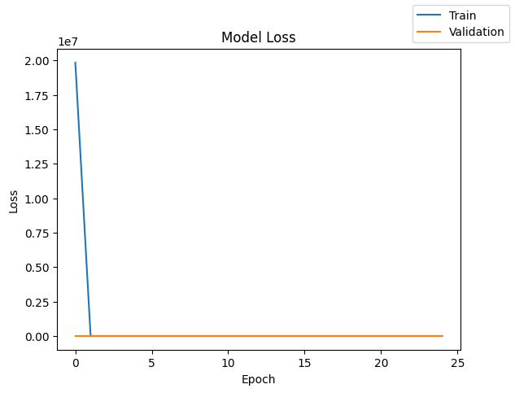

```python
plot(history,'loss')
```

```python
model_0_final_train_perf = model_performance_classification(model, x_train, y_train)
model_0_final_train_perf
```

```
250/250 ━━━━━━━━━━━━━━━━━━━━ 1s 5ms/step
```

|  | Accuracy | Recall | Precision | F1 Score |
| --- | --- | --- | --- | --- |
| 0 | 0.7945 | 0.7945 | 0.63123 | 0.703517 |

```python
model_0_final_test_perf = model_performance_classification(model, x_test, y_test)
model_0_final_test_perf
```

```
63/63 ━━━━━━━━━━━━━━━━━━━━ 0s 3ms/step
```

|  | Accuracy | Recall | Precision | F1 Score |
| --- | --- | --- | --- | --- |
| 0 | 0.8035 | 0.8035 | 0.645612 | 0.715955 |

```python
y_train_pred = model.predict(x_train)
y_valid_pred = model.predict(x_val)
y_test_pred = model.predict(x_test)
```

```
250/250 ━━━━━━━━━━━━━━━━━━━━ 1s 2ms/step
80/80 ━━━━━━━━━━━━━━━━━━━━ 0s 2ms/step
63/63 ━━━━━━━━━━━━━━━━━━━━ 0s 3ms/step
```

```python
print("Classification Report - Train data",end="\n\n")
cr = classification_report(y_train,y_train_pred>0.5)
print(cr)
```

```
Classification Report - Train data

              precision    recall  f1-score   support

           0       0.79      1.00      0.89      6356
           1       0.00      0.00      0.00      1644

    accuracy                           0.79      8000
   macro avg       0.40      0.50      0.44      8000
weighted avg       0.63      0.79      0.70      8000
```

```python
print("Classification Report - Validation data",end="\n\n")
cr = classification_report(y_val,y_valid_pred > 0.5)
print(cr)
```

```
Classification Report - Validation data

              precision    recall  f1-score   support

           0       0.51      1.00      0.68      1303
           1       0.00      0.00      0.00      1240

    accuracy                           0.51      2543
   macro avg       0.26      0.50      0.34      2543
weighted avg       0.26      0.51      0.35      2543
```

```python
print("Classification Report - Test data",end="\n\n")
cr = classification_report(y_test,y_test_pred>0.5)
print(cr)
```

```
Classification Report - Test data

              precision    recall  f1-score   support

           0       0.80      1.00      0.89      1607
           1       0.00      0.00      0.00       393

    accuracy                           0.80      2000
   macro avg       0.40      0.50      0.45      2000
weighted avg       0.65      0.80      0.72      2000
```

- Training Data Report
  - Class 0 (Did not exit):
    - Precision: 0.79, meaning that 79% of predicted class 0 instances were actually class 0.
    - Recall: 1.00, meaning the model predicted all actual class 0 instances correctly.
    - F1-score: 0.89, which is a high score due to perfect recall.
  - Class 1 (Exited):
    - Precision, Recall, F1-score: All are 0, indicating the model did not predict any instances of class 1 correctly. This suggests a complete failure to classify the minority class.
- Validation Data Report
  - Class 0 (Did not exit):
  - Precision: 0.51, meaning 51% of predicted class 0 instances were correct.
  - Recall: 1.00, meaning all actual class 0 instances were predicted correctly.
  - F1-score: 0.68, moderately high due to perfect recall.
  - Class 1 (Exited):
    - Precision, Recall, F1-score: All are 0, meaning the model again failed to identify any class 1 instances. Accuracy: 0.51, which suggests that the model is just slightly better than random guessing, driven entirely by predicting class 0.
- Test Data Report
  - Class 0 (Did not exit):
    - Precision: 0.80, meaning 80% of predicted class 0 instances were correct.
    - Recall: 1.00, meaning the model correctly predicted all class 0 instances.
    - F1-score: 0.89.
  - Class 1 (Exited):
    - Precision, Recall, F1-score: Again, all are 0, showing that the model completely fails to predict the minority class.

Conclusion

- The model is overfitting to the majority class (class 0) and completely ignoring the minority class (class 1), which is common in imbalanced datasets.
- Recall for class 1 is 0 across training, validation, and test datasets, meaning the model is not detecting any of the customers who exited.
- F1-scores for class 1 are also 0, indicating poor overall performance for class 1.

## Actionable Insights and Business Recommendations

Actionable Insights

Business Recommendations

- Improve Customer Engagement Strategies: Customers who actively use the bank’s services are less likely to churn. Thus, increasing engagement through rewards, personalized offers, or financial advice could help improve customer retention.
- Target At-Risk Customers: Even though the model struggled with recall, the features identified (e.g., low balance, few products) provide clues on which types of customers are at a higher risk of leaving. Banks can focus on these customers with targeted campaigns or improved service offerings.
- Address Regional and Demographic Differences: Certain regions and demographics may be more prone to churn. Understanding the specific needs of these customer groups and tailoring services accordingly may reduce churn rates.
- Enhance Data Collection and Balance: Improving the collection of customer feedback, transaction patterns, and product usage data might provide a clearer picture of the reasons behind customer churn. Additionally, further exploration of advanced balancing techniques beyond SMOTE might improve prediction accuracy.

Future Directions

- Experiment with More Advanced Models: The current models, based on neural networks, could be improved by exploring other techniques like gradient boosting machines (GBMs), XGBoost, or ensemble methods to achieve better predictions for the minority class (churning customers).
- Adjust Class Weights: In future iterations, adjusting the class weights in the model’s loss function could help the model focus more on the minority class (class 1), which could improve recall for customers who churn.

Power Ahead